# Base Plotting

Rockefeller University, Bioinformatics Resource Centre

https://rockefelleruniversity.github.io/Plotting_In_R/

These exercises cover base plotting for [Plotting in R](https://rockefelleruniversity.github.io/Plotting_In_R/).

**Exercise 1** - **Base Plots**

- Read in the data “timecourse.csv” as a data.frame and get a summary of column values

```
##       Time         Control1        Control2       Treatment1      Treatment2
##  Min.   : 0.0   Min.   :2.000   Min.   :3.000   Min.   : 3.00   Min.   : 4.0
##  1st Qu.: 2.5   1st Qu.:3.500   1st Qu.:3.500   1st Qu.: 7.00   1st Qu.: 8.5
##  Median : 5.0   Median :5.000   Median :4.000   Median :12.00   Median :13.0
##  Mean   : 5.0   Mean   :4.909   Mean   :4.727   Mean   :10.36   Mean   :11.0
##  3rd Qu.: 7.5   3rd Qu.:6.500   3rd Qu.:6.000   3rd Qu.:14.50   3rd Qu.:14.0
##  Max.   :10.0   Max.   :7.000   Max.   :7.000   Max.   :15.00   Max.   :15.0
```

- Produce a histogram of the values for control and treatment samples

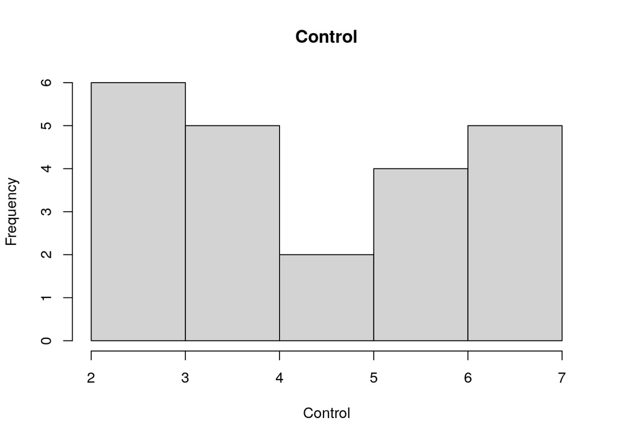

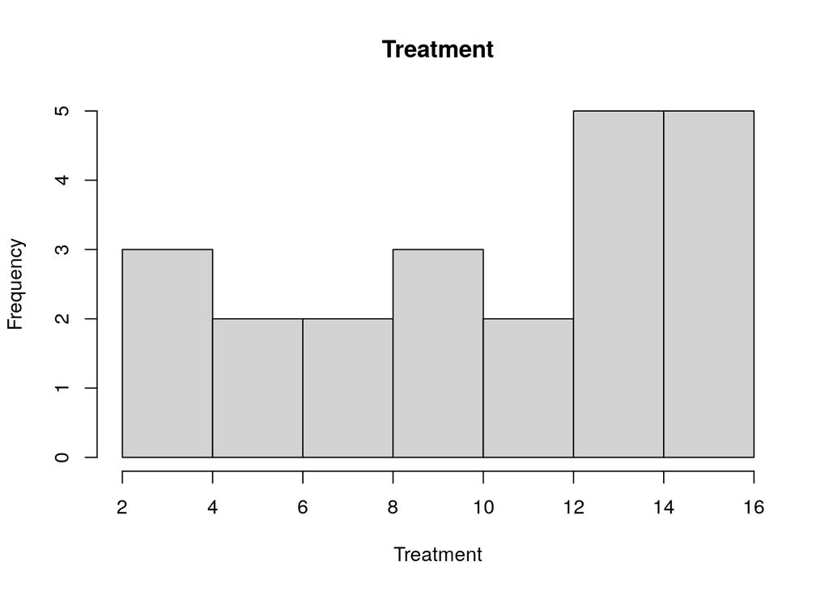

- Put these in the same plot with same X scale limits by modifying the parameters.

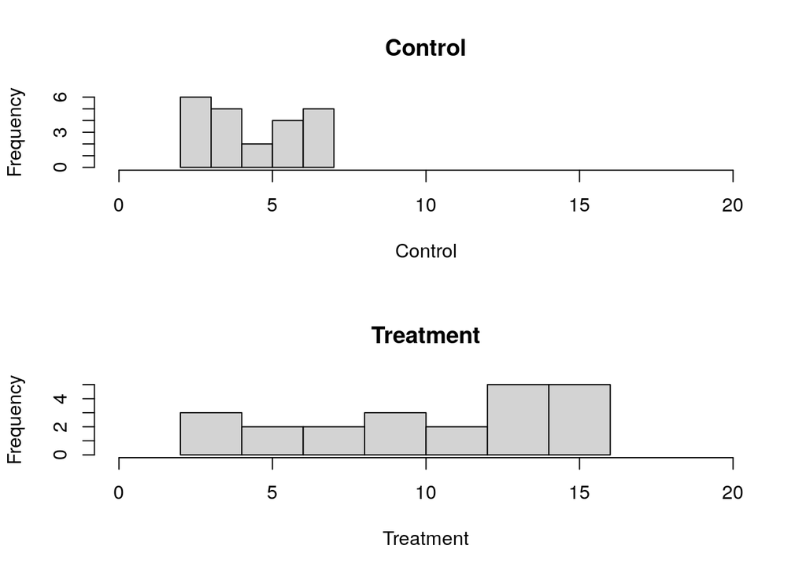

- Make a barplot of values in control sample 1 for every time point. Add a title and color scheme from a palette of your choice.

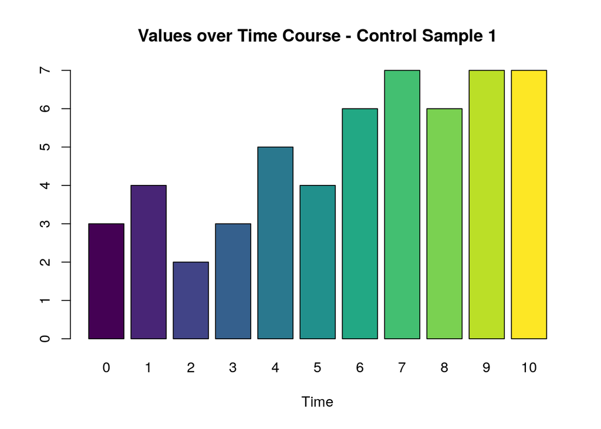

- Use a for loop to plot all 4 samples on a single plot

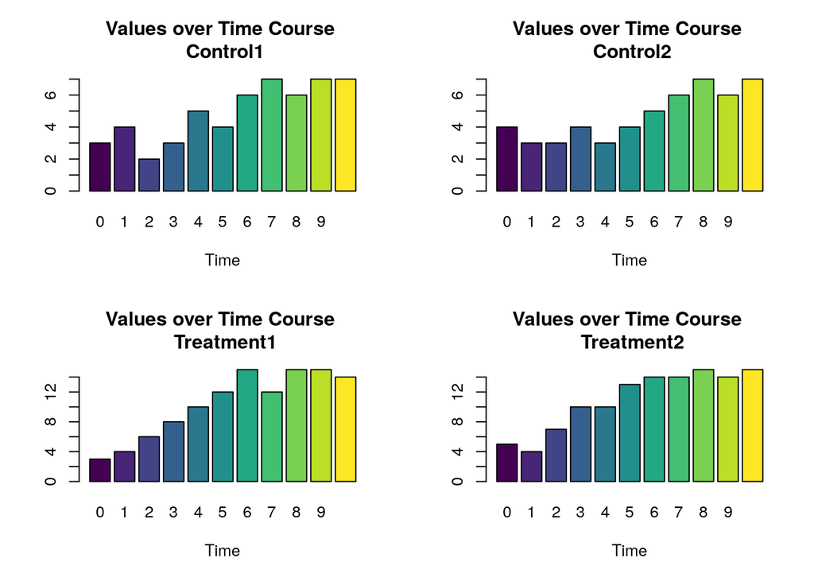

- Make a barplot of mean values in control and treatment samples side by side for every time point

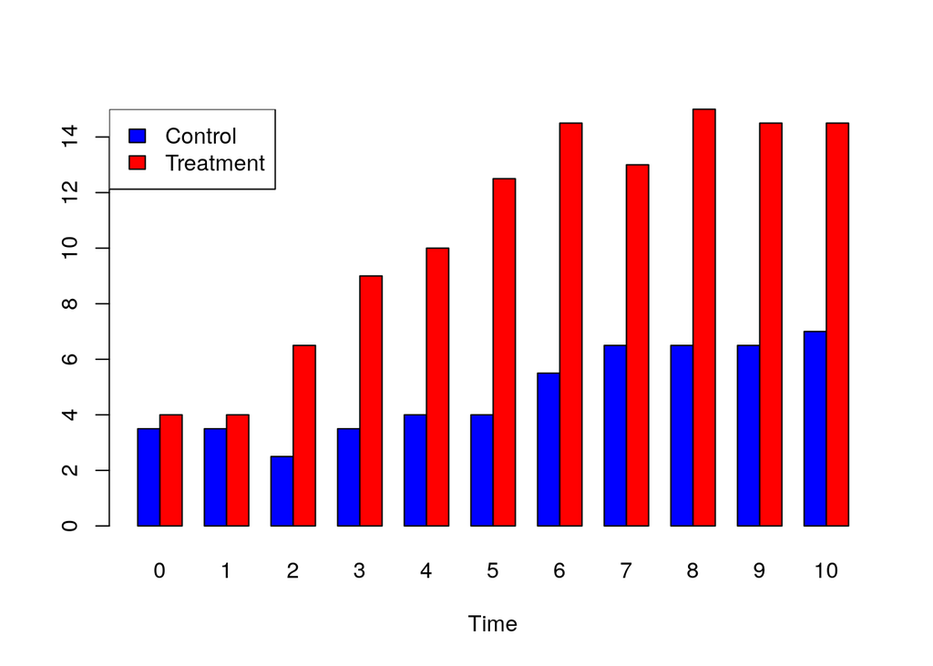

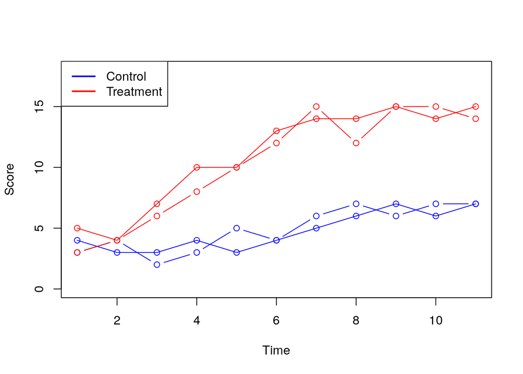

**Exercise 2** - **A working example**

- We will work through some basic analysis of a ecology dataset: salmon catch data. Lets read it in: *salmon_catch_data.csv*. Have a look at what is in the data.

```r
salmon <- read.csv("data/salmon_catch_data.csv")
head(salmon)
```

```
##   salmon_id_number    common_name length_millimeters weight_grams
## 1            35032 Chinook salmon                147         25.6
## 2            35035 Sockeye salmon                121           NA
## 3            35036 Sockeye salmon                112           NA
## 4            35037      Steelhead                220           NA
## 5            35038      Steelhead                152           NA
## 6            35033 Chinook salmon                444       1011.7
```

```r
summary(salmon)
```

```
##  salmon_id_number common_name        length_millimeters  weight_grams
##  Min.   :35032    Length:100         Min.   : 90.0      Min.   :  20.70
##  1st Qu.:35058    Class :character   1st Qu.:147.0      1st Qu.:  25.55
##  Median :35088    Mode  :character   Median :179.5      Median :  28.60
##  Mean   :35089                       Mean   :186.4      Mean   : 142.14
##  3rd Qu.:35120                       3rd Qu.:215.2      3rd Qu.:  46.85
##  Max.   :35147                       Max.   :444.0      Max.   :1011.70
##                                                         NA's   :81
```

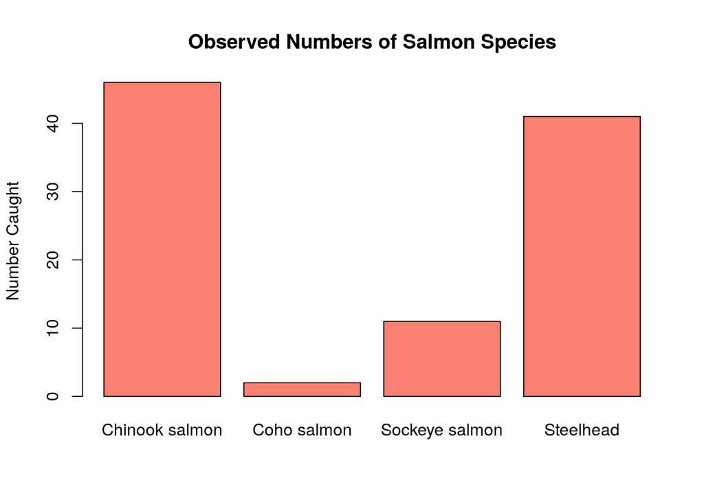

```r
barplot(table(salmon$common_name), col="salmon", ylab = "Number Caught", main="Observed Numbers of Salmon Species")
```

- The two main quantitative measures are length and weight. Lets check if they correlate. Draw a scatter plot to compare these two metrics.

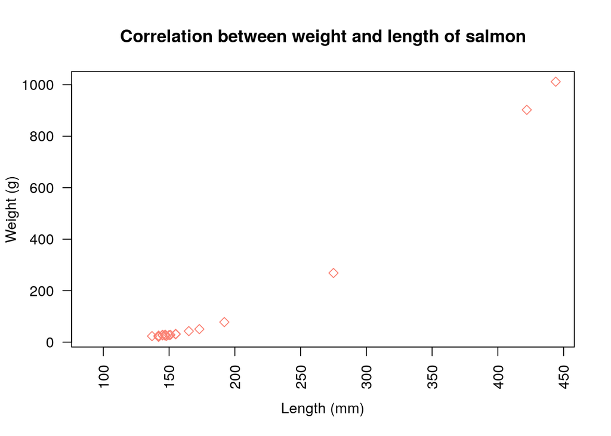

```r
plot(salmon$length_millimeters, salmon$weight_grams, col="salmon", ylab = "Weight (g)", xlab = "Length (mm)", pch=5, main="Correlation between weight and length of salmon", las=2)
```

- For quantitative measures we often want to check their distribution. We’ve shown how to do this in a couple of ways i.e. histograms and violin plots. We want to check the distribution for each species of salmon separately. First lets draw 4 histograms in a grid to show the distribution of length values. Make sure they have the same X axis range.

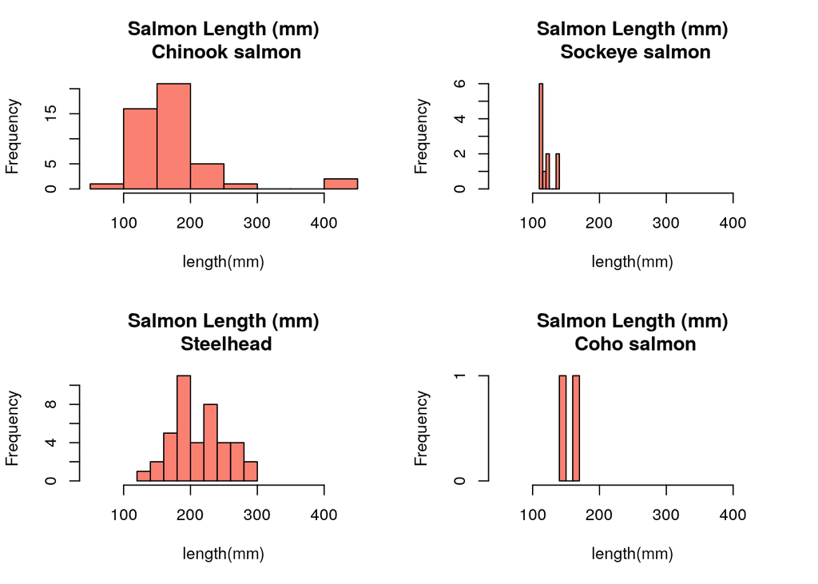

```r
par(mfrow=c(2,2))

salmon_types <- unique(salmon$common_name)
for (i in 1:4){
toplot <- salmon[salmon$common_name %in% salmon_types[i],]
hist(toplot$length_millimeters, xlab = "length(mm)", main = paste("Salmon Length (mm)\n",salmon_types[i]), xlim= c(50,450), col="salmon")
}
```

- Next lets do the same but plot them all on the same violin plot. The data is a different shape to what we used before. Turn off *use.cols* and instead provide a formula *length_millimeters~common_name*. This means look at values of length, split by common_name. Check the help page for more insight in using vioplot().

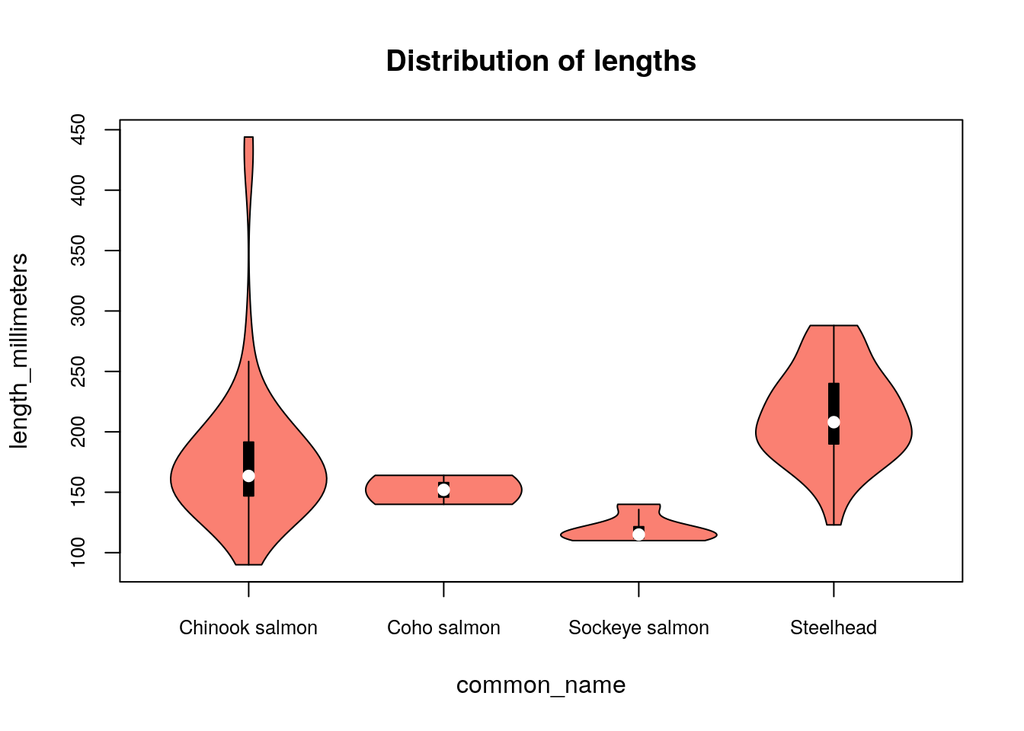

```r
par(mfrow=c(1,1))
library(vioplot)

vioplot(length_millimeters~common_name, data = salmon, use.cols=F, main="Distribution of lengths", col="salmon", cex.axis=0.8)
```

- Lets make a heatmap. The data we currently have read in is not right for a heatmap. Luckily we have another example data set that corresponds to what we have been looking at: salmon_mercury.csv. Read it in and inspect the object. When you read the object in, set the row names as column 1.

```r
salmon_mercury <- read.csv("data/salmon_mercury.csv", row.names = 1)
```

- Lets make a heatmap. The data we currently have read in is not right for a heatmap. Luckily we have another example data set that corresponds to what we have been looking at: salmon_mercury.csv. Read it in and inspect the object.

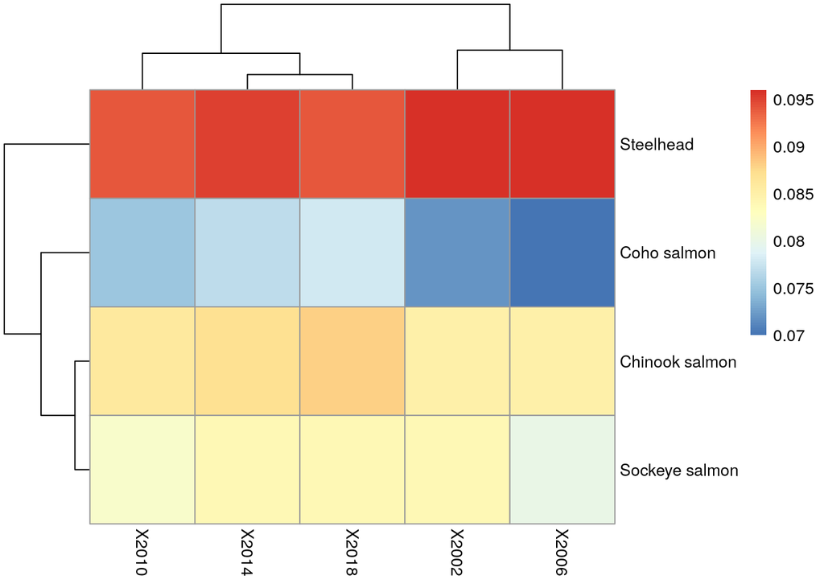

```r
library(pheatmap)
pheatmap(salmon_mercury)
```

- Add a custom color gradient that better fits with data.

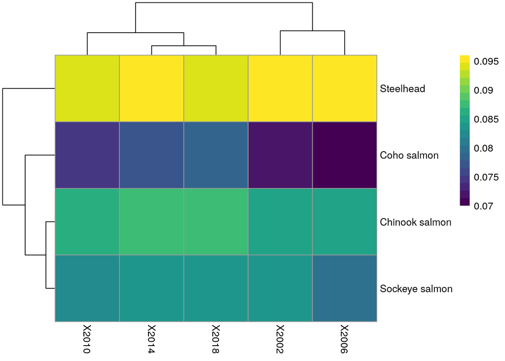

```r
pheatmap(salmon_mercury, color = viridis(20))
```

- Turn off the clustering of clumns so the time series is better represented. Also add a title.

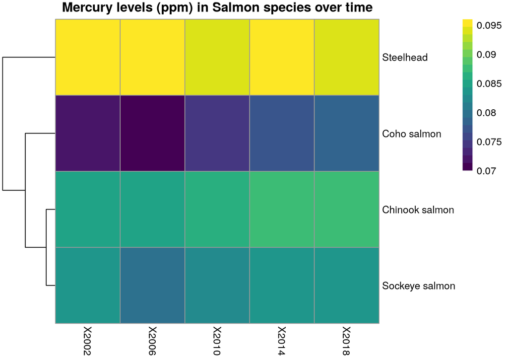

```r
pheatmap(salmon_mercury, color = viridis(20), cluster_cols = F, main="Mercury levels (ppm) in Salmon species over time")
```

- The plot is great so far. It is clear Steelhead have greater levels of Mercury. If we want to see trends though it will be useful to instead scale the data by row.

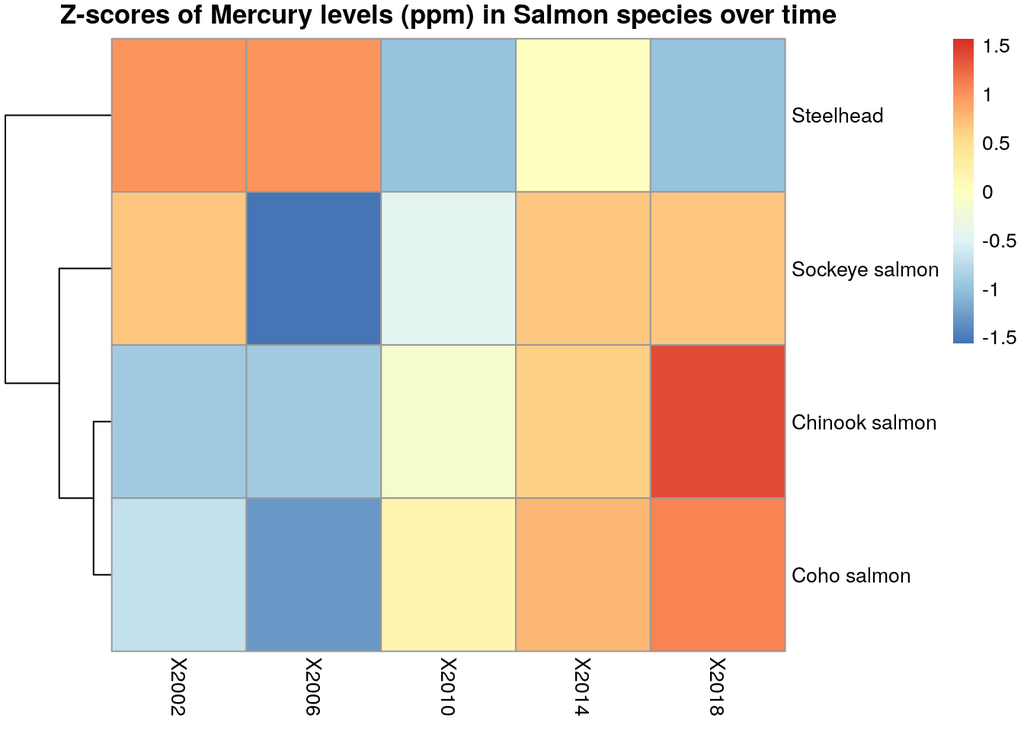

```r
pheatmap(salmon_mercury, scale ="row", cluster_cols = F, main="Z-scores of Mercury levels (ppm) in Salmon species over time")
```

- We can see a nice trend that wasn’t apparent before. Several salmon species seem to have had increasing mercury, while Steelhead is decreasing. Lets finish by updating the color palette to center on white instead of yellow. This will help accurate perception of the color gradient.

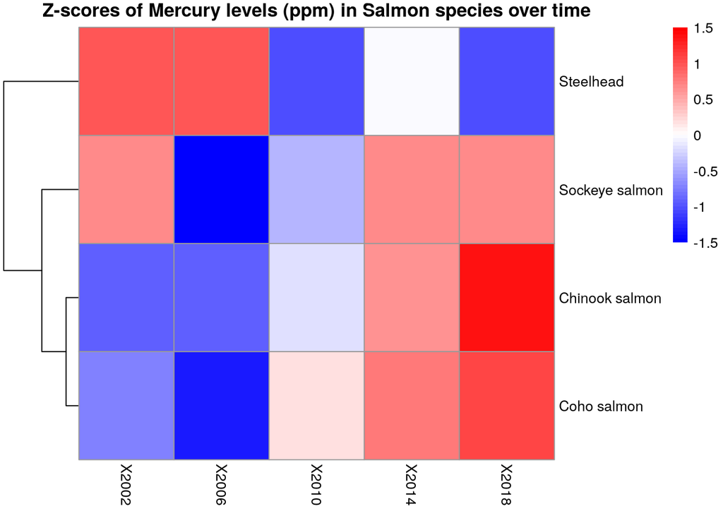

```r
library(RColorBrewer)

my_pal <- colorRampPalette(c("Blue","White","Red"))(60)

pheatmap(salmon_mercury, scale ="row", breaks = seq(-1.5,1.5,0.05), color = my_pal, cluster_cols = F, main="Z-scores of Mercury levels (ppm) in Salmon species over time")
```